# Fundamentos de Pesquisa em Ciência da Computação 2 Lab 2, Checkpoint 4 Artur Alves de Farias

**Objetivo:** Usaremos um problema de exploração de dados que a Wikimedia Foundation usou em 2016 para recrutar pessoas para trabalhar no departamento de descoberta deles. Sua missão é seguir as instruções colocadas na tarefa original, respondendo as 4 perguntas que são colocadas lá.

## Preparação dos dados

Os dados crus oriundos da Wikimedia Foundation são lidos e adicionados à variável **events**.

```r
events = read_csv("../data/events_log.csv.gz")
```

Vamos agrupá-los por **sessão** definindo assim a **unidade de medida**.

Será criado um contador para indicar quantas buscar foram realizadas na mesma sessão. Este contador estará disponível na variável **search_index**.

```r
events = events %>%
    group_by(session_id) %>%
    arrange(timestamp) %>%
    mutate(search_index = cumsum(action == "searchResultPage"))
```

Por fim, como preparação dos dados vamos sumarizar estes dados, agrupando-os assim por **sessão** e **busca** calculando também várias variáveis importantes. Sendo elas:

| Variável | Descrição | Tipo |
| --- | --- | --- |
| session_start_timestamp | Data e hora de início da sessão. | Métrica |
| session_end_timestamp | Data e hora de fim da sessão. | Métrica |
| date | Data da sessão. | Métrica |
| group | Grupo de usuários. | Nominal |
| results | Número de resultados retornados na busca. | Métrica |
| num_clicks | Número de cliques realizados em um dos resultados da busca. | Métrica |
| num_checks | Número de verificações da sessão pelo sistema. | Métrica |
| first_click | Indica em qual resultado o primeiro clique ocorreu. | Métrica |

```r
searches = events %>%
    group_by(session_id, search_index) %>%
    arrange(timestamp) %>%
    summarise(
        session_start_timestamp = first(timestamp),
        session_end_timestamp = last(timestamp),
        date = date(ymd_hms(first(timestamp))),
        group = first(group),
        results = max(n_results, na.rm = TRUE),
        num_clicks = sum(action == "visitPage"),
        num_checks = sum(action == "checkin"),
        first_click = ifelse(num_clicks == 0,
                             NA_integer_,
                             first(na.omit(result_position))
        )
    ) %>%
    filter(search_index > 0)
```

## 1. Qual a taxa de clique geral diária? Como ela varia entre os grupos?

Primeiramente, temos que entender o conceito de **taxa de cliques**. Segundo a Wikimedia, taxa de cliques é a proporção de **sessões de buscas** onde o usuário **clicou** em um dos resultados **exibidos**.

Analisando os dados, vemos que há pesquisas que **não** obtiveram resultados, ou seja, nenhuma possibilidade foi exibida. Ligando esta informação à definição de taxa de cliques, podemos concluir que as consultas que não apresentaram resultados devem ser **desconsideradas** no cálculo da taxa de cliques.

Sendo assim, para as análises deste item 1, as buscas serão filtrados deste modo:

```r
searches_with_results = searches %>%
    filter(results > 0)
```

```r
searches_with_results = searches_with_results %>%
    filter(!(num_clicks > 0 && (is.na(first_click) | first_click <= results)))
```

## 1.1 Qual a taxa de cliques geral diária?

Para o cálculo de taxa de cliques, usaremos a variável **num_click** e **date**. Para suas perguntas derivadas a variável **group**.

| Variável | Descrição | Tipo |
| --- | --- | --- |
| num_clicks | Número de cliques realizados em um dos resultados da busca. | Métrica |
| date | Data da sessão. | Métrica |
| group | Grupo de usuários. | Nominal |

Antes de realizarmos os cálculos, é sempre importante verificar como estão os dados e como é a distribuição das variáveis a serem a analisadas.

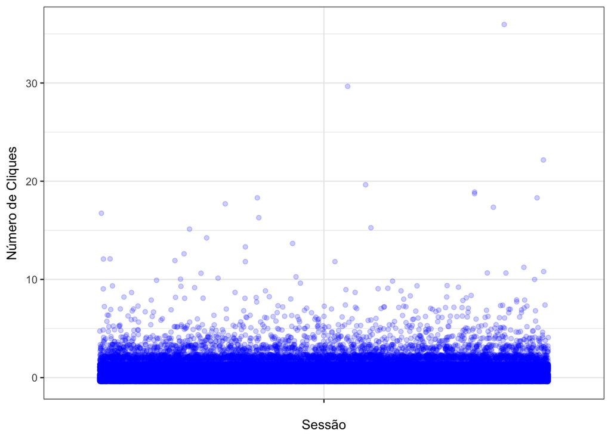

```r
searches_with_results %>%
    ggplot(aes(x = "", y = num_clicks)) +
    geom_jitter(alpha = 0.2, colour = "blue") +
    labs(x = "Sessão", y = "Número de Cliques")
```

Podemos ver uma gigante concentração entre os valores **0** e o **10**, mas muito mais próximo do **0**. Deste modo, assumimos que os usuários clicam **poucas vezes** para cada **sessão de busca**.

Mas em que proporção?

Neste ponto devemos ter **cuidado**, pois a taxa se refere à quando uma sessão **tem** resultado e **é** clicado, e **não quantas vezes** foram os resultados foram clicados.

Deste modo, vamos gerar uma variável nova e correta para esta análise: **has_click**. Ela será derivada do número de cliques, ou seja, quando o número de cliques for maior que zero, esta variável assume o valor de **verdadeiro**.

| Variável | Descrição | Tipo |
| --- | --- | --- |
| has_click | Indica se naquela sessão o usuário clicou em um dos resultados. | Métrica |

Analisando os dados desta nova variável, temos:

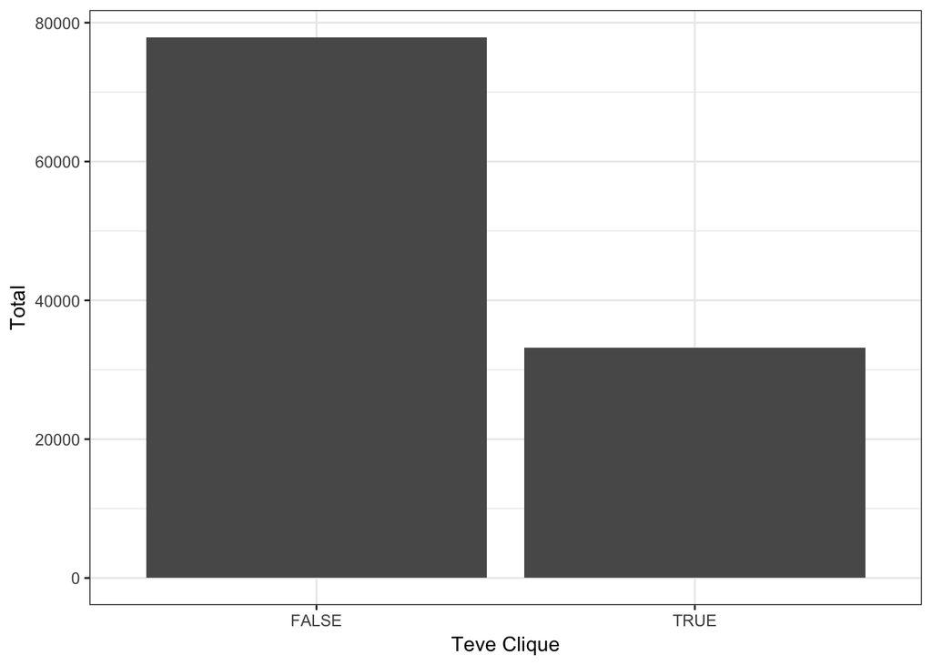

```r
searches_with_results %>%
    mutate(has_click = num_clicks > 0) %>%
    group_by(has_click) %>%
    summarise(
        total = n()
    ) %>%
    ggplot(aes(x = has_click, y = total)) +
    geom_bar(stat="identity") +
    labs(x = "Teve Clique", y = "Total")
```

Agora, iremos calcular a **média** de sessões que tiveram cliques por cada dia. Para isso, somaremos para cada dia, o número de sessões que tiveram cliques e dividiremos pelos número de sessões.

```r
clicks_by_date = searches_with_results %>%
    mutate(has_click = num_clicks > 0) %>%
    group_by("Data" = date) %>%
    summarise(
        "Taxa" = mean(has_click)
    )

clicks_by_date
```

| Data | Taxa |
| --- | --- |
| 2016-03-01 | 0.2922221 |
| 2016-03-02 | 0.2923007 |
| 2016-03-03 | 0.2992492 |
| 2016-03-04 | 0.3066618 |
| 2016-03-05 | 0.3021743 |
| 2016-03-06 | 0.3056986 |
| 2016-03-07 | 0.2956080 |
| 2016-03-08 | 0.2991629 |

Gráfico:

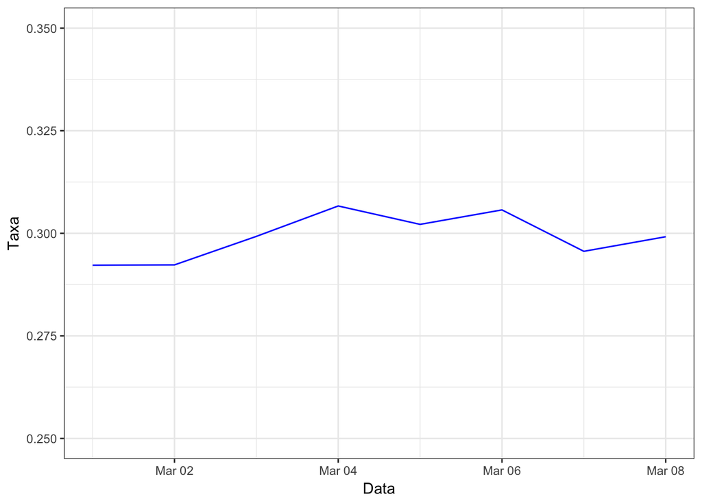

```r
clicks_by_date %>%
    ggplot(aes(x = Data, y = Taxa)) +
    geom_line(colour = "blue") +
    ylim(0.25,0.35)
```

É possível observar que a cada dia as buscas que apresentam resultados tem uma taxa de cliques variando entre **29% a 30%**. Agora, em cima destas **médias diárias**, vamos calcular a média **geral diária**. Iremos então, calcular a **média das médias**, conforme a seguir:

```r
clicks_by_date %>%
    summarise(
        "Taxa" = mean(Taxa)
    )
```

| Taxa |
| --- |
| 0.2991347 |

Por fim, respondendo a **pergunta 1.1**, temos que a taxa de cliques é de aproximadamente **29,9%**. Ou seja, em **29,9%** das vezes que foi **apresentado** resultados aos usuários, eles clicaram em pelo menos um dos resultados.

## 1.2 Como ela varia entre os grupos?

Para esta pergunta sobre a variação entre os grupos, vamos analisar pelo gráfico de barras a diferença entre os grupos.

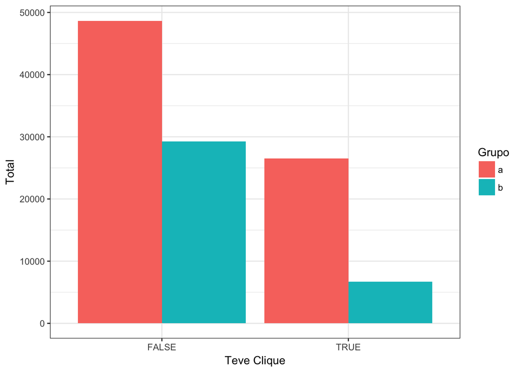

```r
searches_with_results %>%
    mutate(has_click = num_clicks > 0) %>%
    group_by(group, has_click) %>%
    summarise(
        total = n()
    ) %>%
    ggplot(aes(x = has_click, y = total, fill=group)) +
    geom_bar(stat="identity", position=position_dodge()) +
    labs(x = "Teve Clique", y = "Total", fill = "Grupo")
```

Vemos que o grupo “a” não só tem **mais sessões** presentes nos dados como também apresenta uma **diferença menor** entre sessões com e sem clique, do que o grupo “b”.

Calculando em valores absolutos, utilizaremos a **média** agrupadas pelos grupos “a” e “b”.

```r
searches_with_results %>%
    mutate(has_click = num_clicks > 0) %>%
    group_by("Grupo" = group) %>%
    summarise(
        "Média" = mean(has_click)
    )
```

| Grupo | Média |
| --- | --- |
| a | 0.3525428 |
| b | 0.1862153 |

Respondendo a **pergunta 1.2**, temos que o grupo “a” apresenta uma média **superior** perto de **5 pontos percentuais** à média geral, enquanto o grupo “b” apresenta uma média **inferior** próxima de **10 pontos percentuais**.

## 2. Quais resultados as pessoas tendem a tentar primeiro? Como ela muda dia-a-dia?

Há uma variável entre os dados usados que indica qual foi o índice do resultado que o usuário deu o **primeiro clique**. Usaremos esta variável junto da variável que se refere à **data** para responder às duas perguntas.

| Variável | Descrição | Tipo |
| --- | --- | --- |
| first_click | Indica em qual resultado o primeiro clique ocorreu. | Métrica |
| date | Data da sessão. | Métrica |

```r
first_clicks_searches = searches %>%
    ungroup() %>%
    filter(!is.na(first_click)) %>%
    group_by(first_click)

first_clicks_searches %>%
    group_by("Primeiro Clique" = first_click) %>%
    summarise(
        "Total" = n()
    )
```

| Primeiro Clique | Total |
| --- | --- |
| 1 | 21013 |
| 2 | 4705 |
| 3 | 2379 |
| 4 | 1297 |
| 5 | 820 |
| 6 | 574 |
| 7 | 396 |
| 8 | 270 |
| 9 | 225 |
| 10 | 196 |

[output cut: 179 more lines]

Com uma análise prévia dos dados, vemos que após o índice 20, nenhum dos resultados apresenta mais de **10 cliques**, o que gera uma desproporcionalidade na visualização dos gráficos.

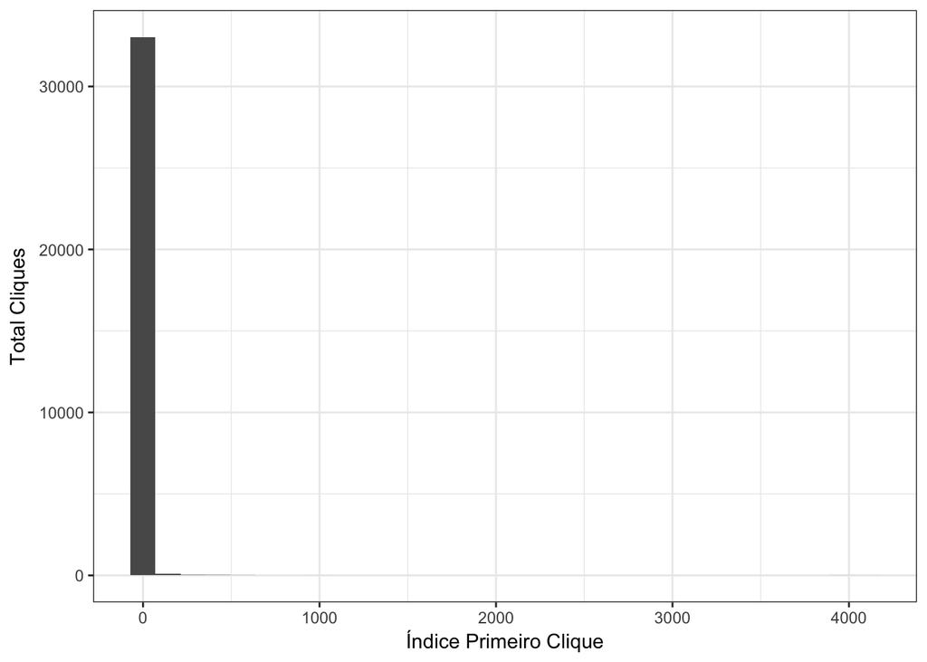

```r
first_clicks_searches %>%
    ggplot(aes(x = first_click)) +
    geom_histogram() +
    labs(x = "Índice Primeiro Clique", y = "Total Cliques")
```

Deste modo, iremos **restringir** os dados para os índices antes do 20.

## 2.1 Quais resultados as pessoas tendem a tentar primeiro?

Agora gerando as mesmas análises dos dados, porém mais restritas, temos:

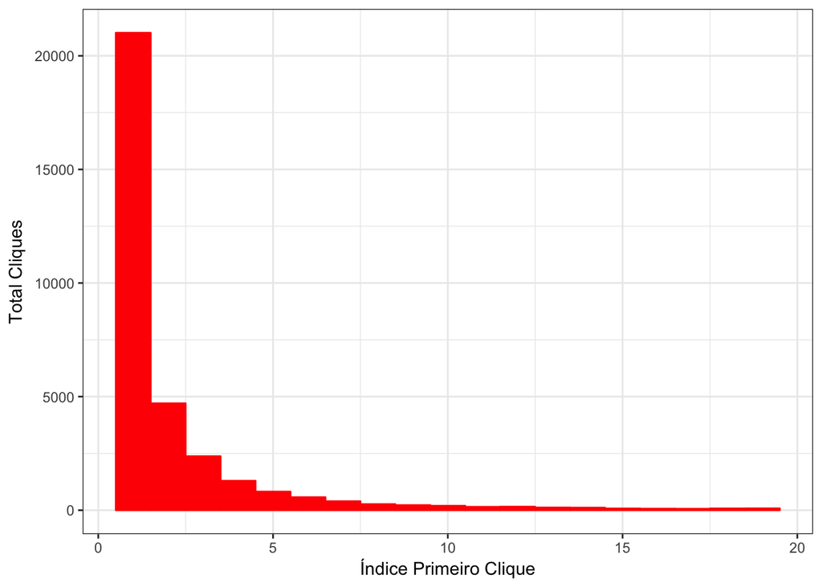

```r
first_clicks_searches_restricted = first_clicks_searches %>%
    filter(first_click < 20)

 first_clicks_searches_restricted %>%
    ggplot(aes(x = first_click)) +
    geom_histogram(binwidth = 1, colour = "red", fill = "red") +
    labs(x = "Índice Primeiro Clique", y = "Total Cliques")
```

Como a pergunta se refere a quais **resultados** as pessoas tendem a tentar primeiro, devemos analisar não só que o **primeiro índice** é disparadamente o mais tentado, como também as demais tentativas tendem a ser **próximas** do primeiro índice.

## 2.2 Como ela muda dia-a-dia?

Para esta pergunta, vamos agrupar os dados não só pelo primeiro clique como também pela **data**.

```r
first_clicks_searches_restricted %>%
    group_by("Data" = date, "Primeiro Clique" = first_click) %>%
    summarise(
        "Total" = n()
    )
```

| Data | Primeiro Clique | Total |
| --- | --- | --- |
| 2016-03-01 | 1 | 2801 |
| 2016-03-01 | 2 | 649 |
| 2016-03-01 | 3 | 282 |
| 2016-03-01 | 4 | 168 |
| 2016-03-01 | 5 | 112 |
| 2016-03-01 | 6 | 61 |
| 2016-03-01 | 7 | 54 |
| 2016-03-01 | 8 | 32 |
| 2016-03-01 | 9 | 26 |
| 2016-03-01 | 10 | 27 |

[output cut: 142 more lines]

Com os dados agrupados, vimos que **não há** uma grande quantidade de datas disponíveis nos dados, ou seja, será possível exibi-los separando-os em gráficos e verificar se o **comportamento** de cada dia é semelhante ou não.

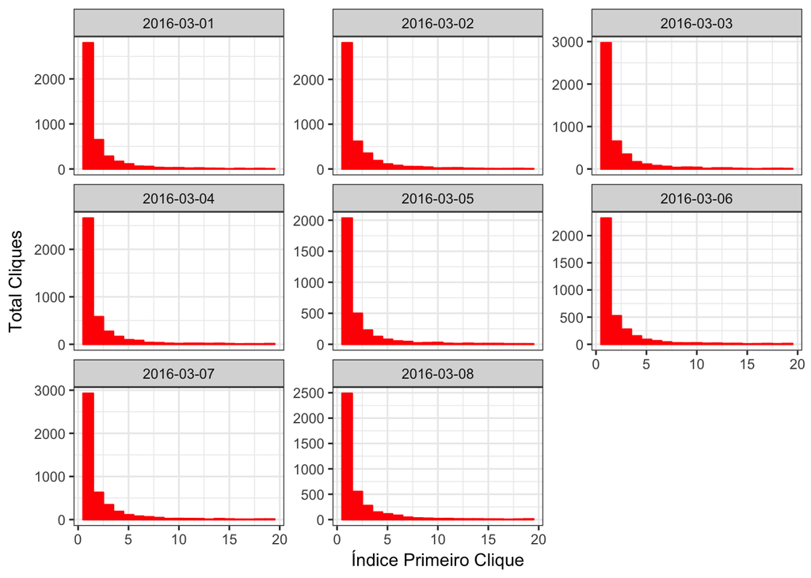

```r
first_clicks_searches_restricted %>%
    group_by(date, first_click) %>%
    ggplot(aes(x = first_click)) +
    facet_wrap(~date, scales = "free_y") +
    geom_histogram(binwidth = 1, colour = "red", fill = "red") +
    labs(x = "Índice Primeiro Clique", y = "Total Cliques")
```

Podemos então, afirmar que independente do dia, o comportamento dos usuários é **semelhante**, pois em todos os gráficos, os usuários tendem a tentar os primeiros resultados em uma frequência bem maior. A medida que um resultado é exibido **posteriormente**, **menor a chance** de o usuário clicá-lo na primeira tentativa.

## 3. Qual é a nossa taxa com resultados zerados geral diária? Como ela varia entre os grupos?

A Wikimedia diz que *zero results*, ou seja, resultados zerados é quando a busca retorna 0 resultados. A proporção deste é quantas buscas obtiveram 0 resultados dentro de todas as buscas realizadas.

Assim iremos usar as variáveis **results** e **date** para responder à primeira pergunta. Para a segunda pergunta usaremos também a variável **group**.

| Variável | Descrição | Tipo |
| --- | --- | --- |
| date | Data da sessão. | Métrica |
| group | Grupo de usuários. | Nominal |
| results | Número de resultados retornados na busca. | Métrica |

## 3.1 Qual é a nossa taxa com resultados zerados geral diária?

Agrupando por **data** e calculando a **média** de buscas sem resultados, temos:

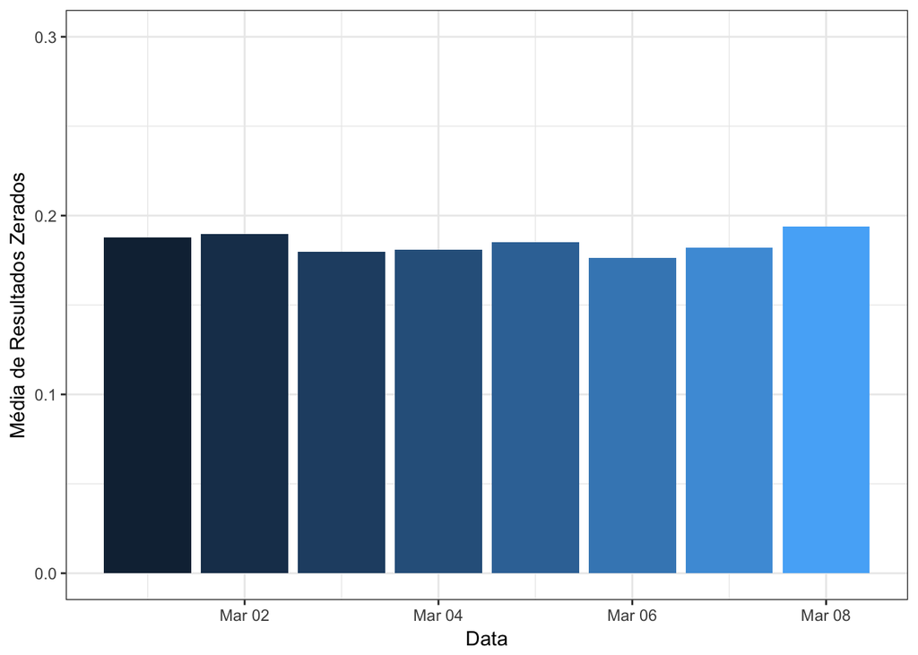

```r
searches %>%
    group_by(date) %>%
    summarise(
        mean = mean(results == 0)
    ) %>%
    ggplot(aes(x = date, y = mean, fill = date)) +
    geom_bar(stat="identity", position=position_dodge()) +
    ylim(0, 0.3) +
    labs(x = "Data", y = "Média de Resultados Zerados") +
    guides(fill=FALSE)
```

É possível notar pelo gráfico que diariamente a taxa de resultados zerados **não varia muito** e se mantém próxima dos **20%**.

Sumarizando esta análise em um valor que represente o valor geral, conforme especificado na pergunta, temos:

```r
searches %>%
    summarise(
        "Média" = mean(results == 0)
    )
```

| Média |
| --- |
| 0.18444 |

Após calcular a **média geral**, temos que **18,4%** das vezes, a busca retorna 0 resultados, o que condiz com a análise do gráfico anteriormente onde os resultados variaram pouco e próximos aos 20%.

## 3.2 Como ela varia entre os grupos?

Para analisarmos a variação entre os grupos, utilizaremos a variável **group** no agrupamento. De modo que temos:

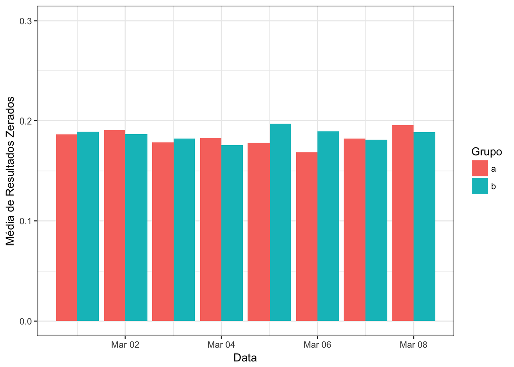

```r
searches %>%
    group_by(date, group) %>%
    summarise(
        mean = mean(results == 0)
    ) %>%
    ggplot(aes(x = date, y = mean, fill = group)) +
    geom_bar(stat="identity", position=position_dodge()) +
    ylim(0, 0.3) +
    labs(x = "Data", y = "Média de Resultados Zerados", fill = "Grupo")
```

Se analisarmos separadamente por data, é possível ver que não há um comportamento padrão para os grupos. Por exmplo, vemos que em algumas datas, o grupo “a” tem mais resultados zerados que o grupo “b”. Já em outras datas, o cenário se inverte. Aparentemente, o **grupo** não tem grande força na relação com **resultados zerados**.

Se desejarmos sumarizar esta avaliação em um único resultado, fazemos:

```r
searches %>%
    group_by("Grupo" = group) %>%
    summarise(
        "Média" = mean(results == 0)
    )
```

| Grupo | Média |
| --- | --- |
| a | 0.1836056 |
| b | 0.1861786 |

Por fim, vemos que de maneira **geral** o grupo “a” tem em média **18,3%** de resultados zerados enquanto o grupo “b” tem em média **18,6%** de resultados zerados.

## 4. Considere a duração da sessão aproximadamente o tempo entre o primeiro evento e o último evento da sessão. Escolha uma variável do conjunto dos dados e descreva seu relacionamento com a duração da sessão. Visualize a relação.

Escolheremos a variável **num_clicks** para vermos a relação entre ela e a **duração da sessão**, ou seja, veremos se os usuários clicam mais vezes por ficarem em sessões maiores.

| Variável | Descrição | Tipo |
| --- | --- | --- |
| session_start_timestamp | Data e hora de início da sessão. | Métrica |
| session_end_timestamp | Data e hora de fim da sessão. | Métrica |
| num_clicks | Número de cliques realizados em um dos resultados da busca. | Métrica |

As variáveis **session_start_timestamp** e **session_end_timestamp** serão utilizados para gerar uma variável nova **session_length**.

| Variável | Descrição | Tipo |
| --- | --- | --- |
| session_length | Duração da sessão em milissegundos (ms). | Métrica |
| num_clicks | Número de cliques realizados em um dos resultados da busca. | Métrica |

```r
searches_with_session_length = searches %>%
    mutate(session_length = session_end_timestamp - session_start_timestamp)

searches_with_session_length %>%
    group_by("Sessão" = session_id) %>%
    summarise(
        "Duração" = sum(session_length)
    )
```

| Sessão | Duração |
| --- | --- |
| 0000cbcb67c19c45 | 0 |
| 0001382e027b2ea4 | 503 |
| 0001e8bb90445cb2 | 715 |
| 000216cf18ae1ab1 | 0 |
| 000527f711d50dfc | 0 |
| 00064fe774048046 | 15 |
| 00071a2cf97168df | 0 |
| 0007582fe23d51e6 | 0 |
| 0007b7f6b575feb6 | 4579 |
| 00086b6ff8156928 | 0 |

[output cut: 9990 more lines]

Analisando os dados do tamanho da sessão, vemos que várias sessões tem tempo de **0 ms**. Isso significa que várias sessões tem o mesmo *timestamp* para o ínicio e o fim, **muito provavelmente**, por terem apenas 1 evento.

De modo, vamos calcular uma **média** de duração destes checks e supor que aproximadamente, as sessões que não tem um segundo evento, foram finalizados antes do primeiro evento de “check”. Deste modo, assumiremos pelo 1 evento de “check” para estas sessões, alterando assim os dados de forma que a duração da sessão terá um valor mínimo.

```r
sessions_with_check_time = searches_with_session_length %>%
    filter(num_checks > 0) %>%
    mutate(
        check_time = session_length / num_checks
    ) %>%
    summarise(
        check_time_mean = mean(check_time)
    )

sessions_with_check_time$check_time_mean
```

```
## [1] 202.0108
```

Portanto, adicionaremos este valor na variável de **duração da sessão** para todas as sessões. Após analisaremos a relação entre as variáveis.

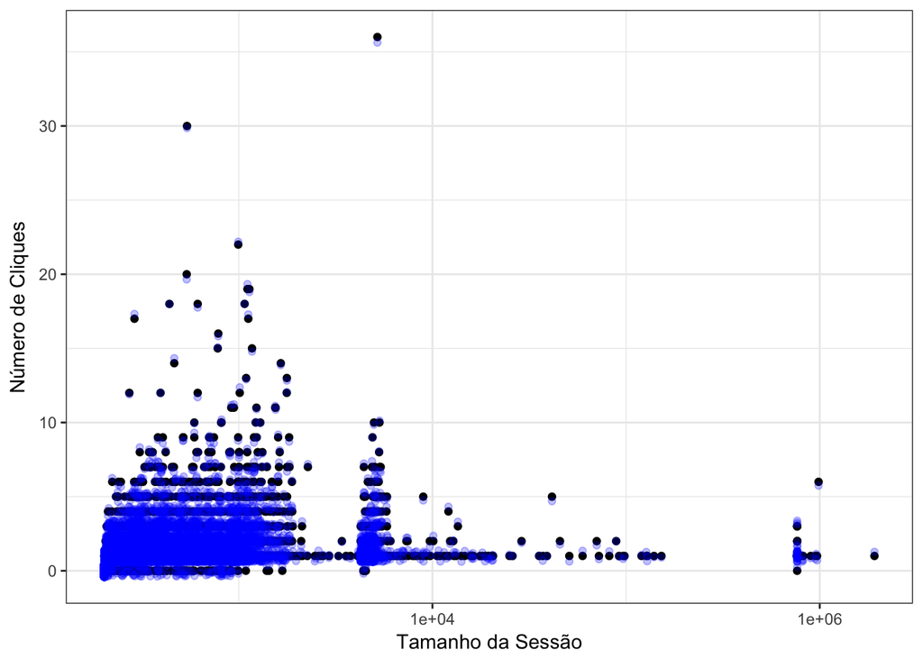

```r
searches_with_session_min = searches_with_session_length %>%
    mutate(session_length_min = session_length + sessions_with_check_time$check_time_mean)

searches_with_session_min %>%
    mutate(session_length_min = session_length + sessions_with_check_time$check_time_mean) %>%
    ggplot(aes(x = session_length_min, y = num_clicks)) +
    geom_point() +
    geom_jitter(alpha = 0.25, colour = "blue") +
    scale_x_log10() +
    labs(x = "Tamanho da Sessão", y = "Número de Cliques")
```

Pelo gráfico, as variáveis **não** apresentam forte relação. Aparentemente, ele possui de maneira geral, um comportamento mais linear, e bem próximo do valor 0 no eixo vertical. Portanto, o método de correlação mais adequado, ao meu ver, é o método de Pearson.

```r
pearson <- cor(searches_with_session_min$session_length_min, searches_with_session_min$num_clicks,  method = "pearson")
```

| Método | Valor |
| --- | --- |
| Pearson | 0.0399988 |

Por fim, concluímos através do métodos de Pearson que realmente **não há** uma forte ligação entre as variáveis, pois seu valor está mais próximo de **ZERO** do que de **UM**.